# Meeting Notes

Joshua delabruere

2/15/2020

First we begin by calling libraries that we want to use. I’m loading the whole tidyverse which includes several libaries like

- ggplot2: Graphics
- dplyr: data manipulation (SQL like)
- tidyr: data tidying/ organizing
- stringr: for string operations

```r
library(tidyverse)
library(tidymodels)
library(randomForest)
library(factoextra)
```

Next, we should load the data. Today we’re looking at the wine dataset which we found at https://www.kaggle.com/brynja/wineuci

I’ve loaded the data on the shared drive

I’ve opted to use the readr packages `read_csv()` function. It has faster read time and leaves more things as characters which avoids changing variables like dates before we decide on a format. This function takes a filepath and reads the data, returning a *data frame* which is matrix like in structure.

```r
wine <- readr::read_csv("wine.csv", col_names = F)
head(wine)
```

```
## # A tibble: 6 x 14
##      X1    X2    X3    X4    X5    X6    X7    X8    X9   X10   X11   X12   X13
##   <dbl> <dbl> <dbl> <dbl> <dbl> <dbl> <dbl> <dbl> <dbl> <dbl> <dbl> <dbl> <dbl>
## 1     1  14.2  1.71  2.43  15.6   127  2.8   3.06  0.28  2.29  5.64  1.04  3.92
## 2     1  13.2  1.78  2.14  11.2   100  2.65  2.76  0.26  1.28  4.38  1.05  3.4
## 3     1  13.2  2.36  2.67  18.6   101  2.8   3.24  0.3   2.81  5.68  1.03  3.17
## 4     1  14.4  1.95  2.5   16.8   113  3.85  3.49  0.24  2.18  7.8   0.86  3.45
## 5     1  13.2  2.59  2.87  21     118  2.8   2.69  0.39  1.82  4.32  1.04  2.93
## 6     1  14.2  1.76  2.45  15.2   112  3.27  3.39  0.34  1.97  6.75  1.05  2.85
## # ... with 1 more variable: X14 <dbl>
```

This data set came without headers, so we’ll have to add column names by themselves. We can do this by creating a *vector*. A vector is a list, but all items must be the same type. A data frame is composed of vectors of the same length. Each vector represents a variable in a data frame.

we can create a vector using `c(item1, item2, ... itemn)`

Remember in R we use `<-` instead of `=` for variable asignment like `variable <- 1+4`. We can use `=` for assignment, but R best practices discourages this and reserves `=` for equivelence checks.

variables names are as follows:

- cultivar: The varaity of wine
- alcohol:
- malic_acid:
- ash
- alcalinity_ash
- magnesium
- total_phenols
- flavanoids
- non_flavnoid_phenols
- proanthocyanins
- color_intensity
- hue
- od
- proline

We can also use the function `names(data_frame_name)` to access the column names of a data frame. We will assign our list of variable names to the names of our data frame.

```r
varNames <- c('cultivar', 'alcohol', 'malic_acid', 'ash', 'alcalinity_ash', 'magnesium', 'total_phenols', 'flavanoids', 'non_flavnoid_phenols', 'proanthocyanins', 'color_intensity', 'hue', 'od', 'proline')

names(wine) <- varNames

head(wine)
```

```
## # A tibble: 6 x 14
##   cultivar alcohol malic_acid   ash alcalinity_ash magnesium total_phenols
##      <dbl>   <dbl>      <dbl> <dbl>          <dbl>     <dbl>         <dbl>
## 1        1    14.2       1.71  2.43           15.6       127          2.8
## 2        1    13.2       1.78  2.14           11.2       100          2.65
## 3        1    13.2       2.36  2.67           18.6       101          2.8
## 4        1    14.4       1.95  2.5            16.8       113          3.85
## 5        1    13.2       2.59  2.87           21         118          2.8
## 6        1    14.2       1.76  2.45           15.2       112          3.27
## # ... with 7 more variables: flavanoids <dbl>, non_flavnoid_phenols <dbl>,
## #   proanthocyanins <dbl>, color_intensity <dbl>, hue <dbl>, od <dbl>,
## #   proline <dbl>
```

Next lets get the summary statistics of our data set. We can use the `summary()` command to get summary statistics.

```r
summary(wine)
```

```
##     cultivar        alcohol        malic_acid         ash
##  Min.   :1.000   Min.   :11.03   Min.   :0.740   Min.   :1.360
##  1st Qu.:1.000   1st Qu.:12.36   1st Qu.:1.603   1st Qu.:2.210
##  Median :2.000   Median :13.05   Median :1.865   Median :2.360
##  Mean   :1.938   Mean   :13.00   Mean   :2.336   Mean   :2.367
##  3rd Qu.:3.000   3rd Qu.:13.68   3rd Qu.:3.083   3rd Qu.:2.558
##  Max.   :3.000   Max.   :14.83   Max.   :5.800   Max.   :3.230
##  alcalinity_ash    magnesium      total_phenols     flavanoids
##  Min.   :10.60   Min.   : 70.00   Min.   :0.980   Min.   :0.340
##  1st Qu.:17.20   1st Qu.: 88.00   1st Qu.:1.742   1st Qu.:1.205
##  Median :19.50   Median : 98.00   Median :2.355   Median :2.135
##  Mean   :19.49   Mean   : 99.74   Mean   :2.295   Mean   :2.029
##  3rd Qu.:21.50   3rd Qu.:107.00   3rd Qu.:2.800   3rd Qu.:2.875
##  Max.   :30.00   Max.   :162.00   Max.   :3.880   Max.   :5.080
##  non_flavnoid_phenols proanthocyanins color_intensity       hue
##  Min.   :0.1300       Min.   :0.410   Min.   : 1.280   Min.   :0.4800
##  1st Qu.:0.2700       1st Qu.:1.250   1st Qu.: 3.220   1st Qu.:0.7825
##  Median :0.3400       Median :1.555   Median : 4.690   Median :0.9650
##  Mean   :0.3619       Mean   :1.591   Mean   : 5.058   Mean   :0.9574
##  3rd Qu.:0.4375       3rd Qu.:1.950   3rd Qu.: 6.200   3rd Qu.:1.1200
##  Max.   :0.6600       Max.   :3.580   Max.   :13.000   Max.   :1.7100
##        od           proline
##  Min.   :1.270   Min.   : 278.0
##  1st Qu.:1.938   1st Qu.: 500.5
##  Median :2.780   Median : 673.5
##  Mean   :2.612   Mean   : 746.9
##  3rd Qu.:3.170   3rd Qu.: 985.0
##  Max.   :4.000   Max.   :1680.0
```

Notice that cultivar is being treated as a number rather than a factor. We can fix that using `as.factor()`. We can directly access a column in the data frame using `df$varName` so for us, `wine$cultivar` **Or** we can use `wine[,1]`

```r
wine$cultivar <- as.factor(wine$cultivar)
summary(wine)
```

```
##  cultivar    alcohol        malic_acid         ash        alcalinity_ash
##  1:59     Min.   :11.03   Min.   :0.740   Min.   :1.360   Min.   :10.60
##  2:71     1st Qu.:12.36   1st Qu.:1.603   1st Qu.:2.210   1st Qu.:17.20
##  3:48     Median :13.05   Median :1.865   Median :2.360   Median :19.50
##           Mean   :13.00   Mean   :2.336   Mean   :2.367   Mean   :19.49
##           3rd Qu.:13.68   3rd Qu.:3.083   3rd Qu.:2.558   3rd Qu.:21.50
##           Max.   :14.83   Max.   :5.800   Max.   :3.230   Max.   :30.00
##    magnesium      total_phenols     flavanoids    non_flavnoid_phenols
##  Min.   : 70.00   Min.   :0.980   Min.   :0.340   Min.   :0.1300
##  1st Qu.: 88.00   1st Qu.:1.742   1st Qu.:1.205   1st Qu.:0.2700
##  Median : 98.00   Median :2.355   Median :2.135   Median :0.3400
##  Mean   : 99.74   Mean   :2.295   Mean   :2.029   Mean   :0.3619
##  3rd Qu.:107.00   3rd Qu.:2.800   3rd Qu.:2.875   3rd Qu.:0.4375
##  Max.   :162.00   Max.   :3.880   Max.   :5.080   Max.   :0.6600
##  proanthocyanins color_intensity       hue               od
##  Min.   :0.410   Min.   : 1.280   Min.   :0.4800   Min.   :1.270
##  1st Qu.:1.250   1st Qu.: 3.220   1st Qu.:0.7825   1st Qu.:1.938
##  Median :1.555   Median : 4.690   Median :0.9650   Median :2.780
##  Mean   :1.591   Mean   : 5.058   Mean   :0.9574   Mean   :2.612
##  3rd Qu.:1.950   3rd Qu.: 6.200   3rd Qu.:1.1200   3rd Qu.:3.170
##  Max.   :3.580   Max.   :13.000   Max.   :1.7100   Max.   :4.000
##     proline
##  Min.   : 278.0
##  1st Qu.: 500.5
##  Median : 673.5
##  Mean   : 746.9
##  3rd Qu.: 985.0
##  Max.   :1680.0
```

We can use data visualization to examine the relationships between various variables. I used a heatmap to look at how correlated the various columns were. for correlation we need all columns to be numeric, so let’s exclude column 1 from our data set using `wine[,-c(1)]` we can remove the values I’ve set to na for slight clustering with dendograms

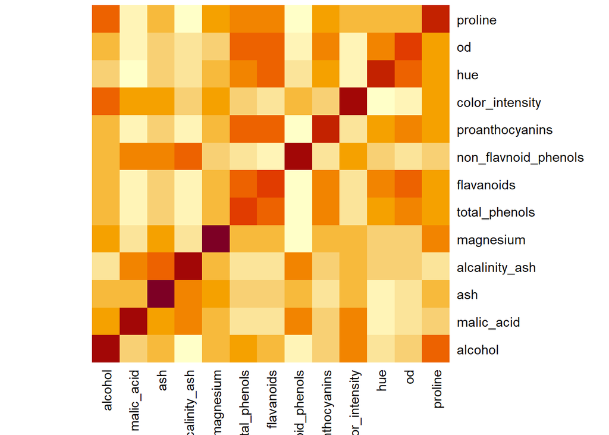

```r
heatmap(cor(wine[,-c(1)]), Rowv = NA, Colv = NA)
```

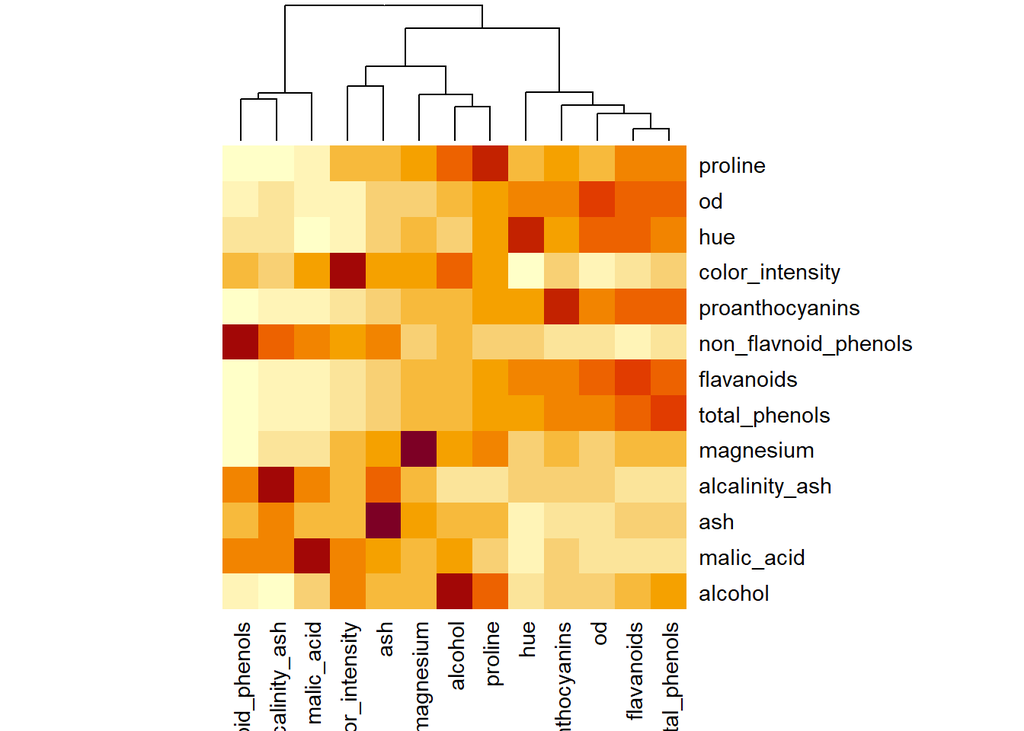

```r
heatmap(cor(wine[,-c(1)]), Rowv = NA)
```

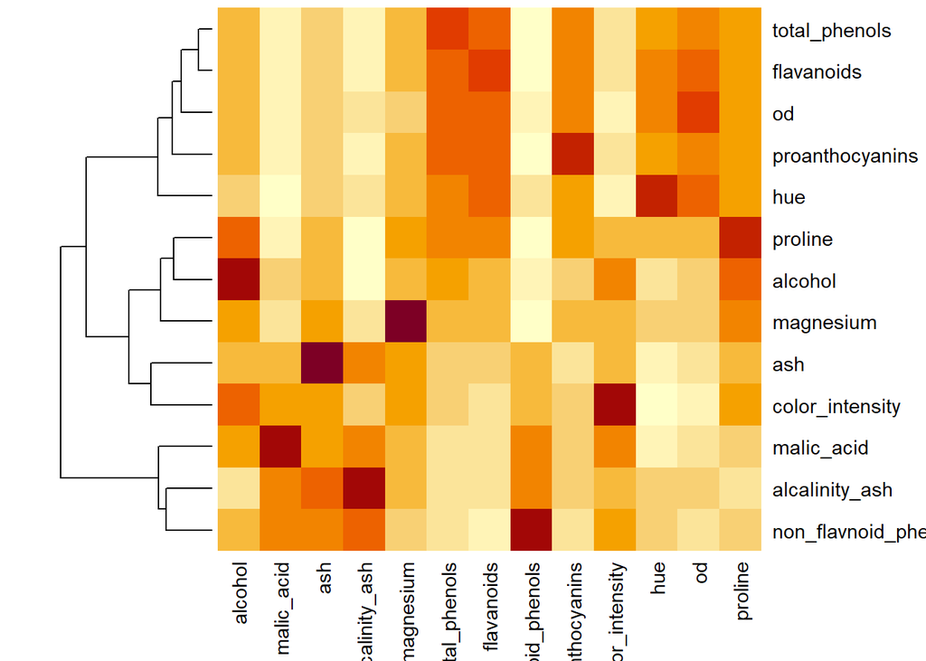

```r
heatmap(cor(wine[,-c(1)]), Colv = NA)
```

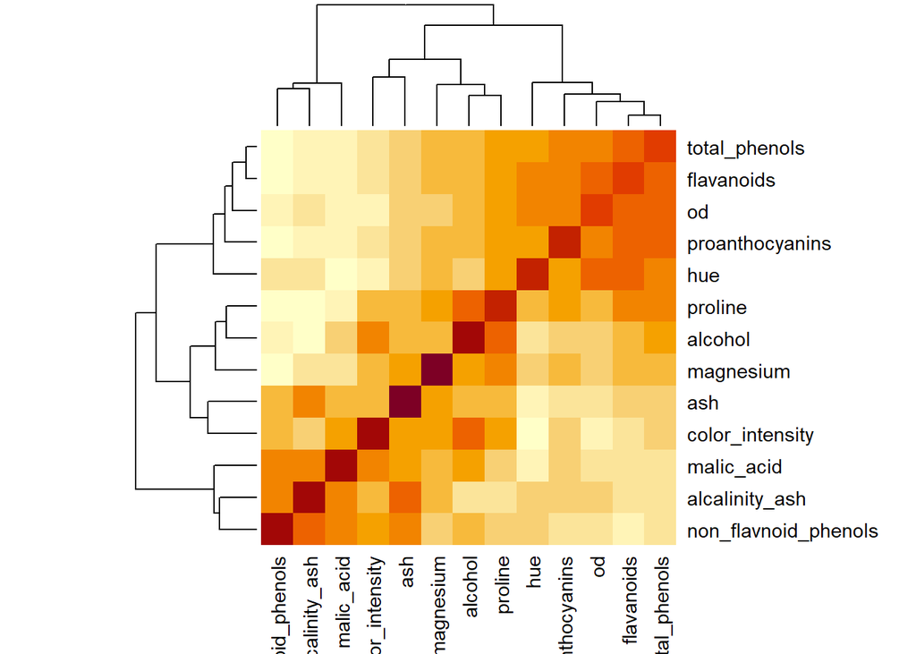

```r
heatmap(cor(wine[,-c(1)]))
```

Looking at the darker squares we can see which variables are closely related.

We can also plot the data set to create a cor plot using `plot(wine)`

Play around with the variables you include as this is pretty cluttered. You can exclude variables by putting a negative vector `-c(1,2,3)` exculudes the first 3 columns. You can also specifically include variables by using a regular vector `c(4,5,6)` includes the columns 4,5, and 6.

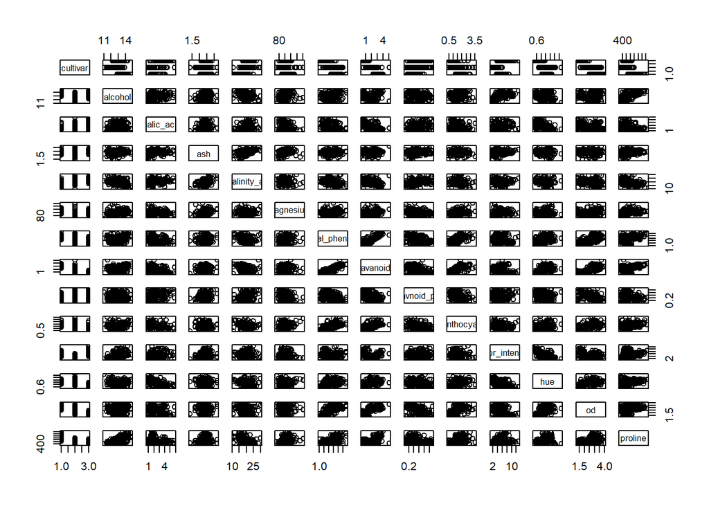

```r
plot(wine)
```

We want to classify today, and the easiest column to do that with is cultivar. However, we have 3 categories, which while possible, is a little more indepth than a binary classification. lets use dplyr functions to create a new variable wine_type where we’re trying to identify wines from cultivar #2

dplyr (and the rest of tidyverse) use the *`%>%`* operator which is refered to as piping to pass a *data frame* like object called a *tibble* between functions which have the first argument of data and return a data frame/tibble. I think this is easier to understand in practice, so look at the example below. For this problem we’re using `mutate()` to create a new variable and `select()` to select columns.